# Risk Factor Analysis

## Outcome Variable

**Outcome Variable:** dead

## Predictor Variables

**Intervention Variable:** ever_sstunted06

**Adjustment Set:**

unadjusted

## Stratifying Variables

The analysis was stratified on these variable(s):

- studyid
- country

## Data Summary

| studyid | country | ever_sstunted06 | dead | n_cell | n |
| --- | --- | --- | --- | --- | --- |
| Burkina Faso Zn | BURKINA FASO | 0 | 0 | 325 | 338 |
| Burkina Faso Zn | BURKINA FASO | 0 | 1 | 2 | 338 |
| Burkina Faso Zn | BURKINA FASO | 1 | 0 | 11 | 338 |
| Burkina Faso Zn | BURKINA FASO | 1 | 1 | 0 | 338 |
| EE | PAKISTAN | 0 | 0 | 213 | 379 |
| EE | PAKISTAN | 0 | 1 | 3 | 379 |
| EE | PAKISTAN | 1 | 0 | 162 | 379 |
| EE | PAKISTAN | 1 | 1 | 1 | 379 |
| GMS-Nepal | NEPAL | 0 | 0 | 634 | 698 |
| GMS-Nepal | NEPAL | 0 | 1 | 4 | 698 |
| GMS-Nepal | NEPAL | 1 | 0 | 56 | 698 |
| GMS-Nepal | NEPAL | 1 | 1 | 4 | 698 |
| iLiNS-DOSE | MALAWI | 0 | 0 | 1588 | 1813 |
| iLiNS-DOSE | MALAWI | 0 | 1 | 101 | 1813 |
| iLiNS-DOSE | MALAWI | 1 | 0 | 111 | 1813 |
| iLiNS-DOSE | MALAWI | 1 | 1 | 13 | 1813 |
| iLiNS-DYAD-M | MALAWI | 0 | 0 | 1066 | 1191 |
| iLiNS-DYAD-M | MALAWI | 0 | 1 | 34 | 1191 |
| iLiNS-DYAD-M | MALAWI | 1 | 0 | 86 | 1191 |
| iLiNS-DYAD-M | MALAWI | 1 | 1 | 5 | 1191 |
| JiVitA-3 | BANGLADESH | 0 | 0 | 22511 | 27197 |
| JiVitA-3 | BANGLADESH | 0 | 1 | 435 | 27197 |
| JiVitA-3 | BANGLADESH | 1 | 0 | 3885 | 27197 |
| JiVitA-3 | BANGLADESH | 1 | 1 | 366 | 27197 |
| JiVitA-4 | BANGLADESH | 0 | 0 | 4639 | 5270 |
| JiVitA-4 | BANGLADESH | 0 | 1 | 31 | 5270 |
| JiVitA-4 | BANGLADESH | 1 | 0 | 584 | 5270 |
| JiVitA-4 | BANGLADESH | 1 | 1 | 16 | 5270 |
| Keneba | GAMBIA | 0 | 0 | 2142 | 2479 |
| Keneba | GAMBIA | 0 | 1 | 43 | 2479 |
| Keneba | GAMBIA | 1 | 0 | 278 | 2479 |
| Keneba | GAMBIA | 1 | 1 | 16 | 2479 |
| MAL-ED | BANGLADESH | 0 | 0 | 240 | 265 |
| MAL-ED | BANGLADESH | 0 | 1 | 2 | 265 |
| MAL-ED | BANGLADESH | 1 | 0 | 22 | 265 |
| MAL-ED | BANGLADESH | 1 | 1 | 1 | 265 |
| MAL-ED | INDIA | 0 | 0 | 228 | 251 |
| MAL-ED | INDIA | 0 | 1 | 2 | 251 |
| MAL-ED | INDIA | 1 | 0 | 21 | 251 |
| MAL-ED | INDIA | 1 | 1 | 0 | 251 |
| MAL-ED | PERU | 0 | 0 | 260 | 303 |
| MAL-ED | PERU | 0 | 1 | 2 | 303 |
| MAL-ED | PERU | 1 | 0 | 41 | 303 |
| MAL-ED | PERU | 1 | 1 | 0 | 303 |
| MAL-ED | SOUTH AFRICA | 0 | 0 | 283 | 314 |
| MAL-ED | SOUTH AFRICA | 0 | 1 | 0 | 314 |
| MAL-ED | SOUTH AFRICA | 1 | 0 | 30 | 314 |
| MAL-ED | SOUTH AFRICA | 1 | 1 | 1 | 314 |
| MAL-ED | TANZANIA, UNITED REPUBLIC OF | 0 | 0 | 219 | 262 |
| MAL-ED | TANZANIA, UNITED REPUBLIC OF | 0 | 1 | 2 | 262 |
| MAL-ED | TANZANIA, UNITED REPUBLIC OF | 1 | 0 | 40 | 262 |
| MAL-ED | TANZANIA, UNITED REPUBLIC OF | 1 | 1 | 1 | 262 |
| PROVIDE | BANGLADESH | 0 | 0 | 665 | 700 |
| PROVIDE | BANGLADESH | 0 | 1 | 4 | 700 |
| PROVIDE | BANGLADESH | 1 | 0 | 31 | 700 |
| PROVIDE | BANGLADESH | 1 | 1 | 0 | 700 |
| SAS-CompFeed | INDIA | 0 | 0 | 1266 | 1532 |
| SAS-CompFeed | INDIA | 0 | 1 | 29 | 1532 |
| SAS-CompFeed | INDIA | 1 | 0 | 216 | 1532 |
| SAS-CompFeed | INDIA | 1 | 1 | 21 | 1532 |
| SAS-FoodSuppl | INDIA | 0 | 0 | 351 | 418 |
| SAS-FoodSuppl | INDIA | 0 | 1 | 3 | 418 |
| SAS-FoodSuppl | INDIA | 1 | 0 | 61 | 418 |
| SAS-FoodSuppl | INDIA | 1 | 1 | 3 | 418 |
| TanzaniaChild2 | TANZANIA, UNITED REPUBLIC OF | 0 | 0 | 2284 | 2396 |
| TanzaniaChild2 | TANZANIA, UNITED REPUBLIC OF | 0 | 1 | 1 | 2396 |
| TanzaniaChild2 | TANZANIA, UNITED REPUBLIC OF | 1 | 0 | 111 | 2396 |
| TanzaniaChild2 | TANZANIA, UNITED REPUBLIC OF | 1 | 1 | 0 | 2396 |
| VITAMIN-A | INDIA | 0 | 0 | 3274 | 3898 |
| VITAMIN-A | INDIA | 0 | 1 | 50 | 3898 |
| VITAMIN-A | INDIA | 1 | 0 | 547 | 3898 |
| VITAMIN-A | INDIA | 1 | 1 | 27 | 3898 |
| ZVITAMBO | ZIMBABWE | 0 | 0 | 11756 | 14060 |
| ZVITAMBO | ZIMBABWE | 0 | 1 | 871 | 14060 |
| ZVITAMBO | ZIMBABWE | 1 | 0 | 1199 | 14060 |
| ZVITAMBO | ZIMBABWE | 1 | 1 | 234 | 14060 |

The following strata were considered:

- studyid: Burkina Faso Zn, country: BURKINA FASO
- studyid: EE, country: PAKISTAN
- studyid: GMS-Nepal, country: NEPAL
- studyid: iLiNS-DOSE, country: MALAWI
- studyid: iLiNS-DYAD-M, country: MALAWI
- studyid: JiVitA-3, country: BANGLADESH
- studyid: JiVitA-4, country: BANGLADESH
- studyid: Keneba, country: GAMBIA
- studyid: MAL-ED, country: BANGLADESH
- studyid: MAL-ED, country: INDIA
- studyid: MAL-ED, country: PERU
- studyid: MAL-ED, country: SOUTH AFRICA
- studyid: MAL-ED, country: TANZANIA, UNITED REPUBLIC OF
- studyid: PROVIDE, country: BANGLADESH
- studyid: SAS-CompFeed, country: INDIA
- studyid: SAS-FoodSuppl, country: INDIA
- studyid: TanzaniaChild2, country: TANZANIA, UNITED REPUBLIC OF
- studyid: VITAMIN-A, country: INDIA
- studyid: ZVITAMBO, country: ZIMBABWE

### Dropped Strata

Some strata were dropped due to rare outcomes:

- studyid: Burkina Faso Zn, country: BURKINA FASO
- studyid: EE, country: PAKISTAN
- studyid: GMS-Nepal, country: NEPAL
- studyid: MAL-ED, country: BANGLADESH
- studyid: MAL-ED, country: INDIA
- studyid: MAL-ED, country: PERU
- studyid: MAL-ED, country: SOUTH AFRICA
- studyid: MAL-ED, country: TANZANIA, UNITED REPUBLIC OF
- studyid: PROVIDE, country: BANGLADESH
- studyid: SAS-FoodSuppl, country: INDIA
- studyid: TanzaniaChild2, country: TANZANIA, UNITED REPUBLIC OF

## Methods Detail

We’re interested in the causal parameters $E[Y_a]$ for all values of $a \in \mathcal{A}$. These parameters represent the mean outcome if, possibly contrary to fact, we intervened to set all units to have $A=a$. Under the randomization and positivity assumptions, these are identified by the statistical parameters $\psi_a=E_W[E_{Y|A,W}(Y|A=a,W)]$. In addition, we’re interested in the mean of $Y$, $E[Y]$ under no intervention (the observed mean). We will estimate these parameters by using SuperLearner to fit the relevant likelihood factors – $E_{Y|A,W}(Y|A=a,W)$ and $p(A=a|W)$, and then updating our likelihood fit using a joint TMLE.

For unadjusted analyses ($W=\{\}$), initial likelihoods were estimated using Lrnr_glm to estimate the simple $E(Y|A)$ and Lrnr_mean to estimate $p(A)$. For adjusted analyses, a small library containing Lrnr_glmnet, Lrnr_xgboost, and Lrnr_mean was used.

Having estimated these parameters, we will then use the delta method to estimate relative risks and attributable risks relative to a prespecified baseline level of $A$.

# Results Detail

## Results Plots

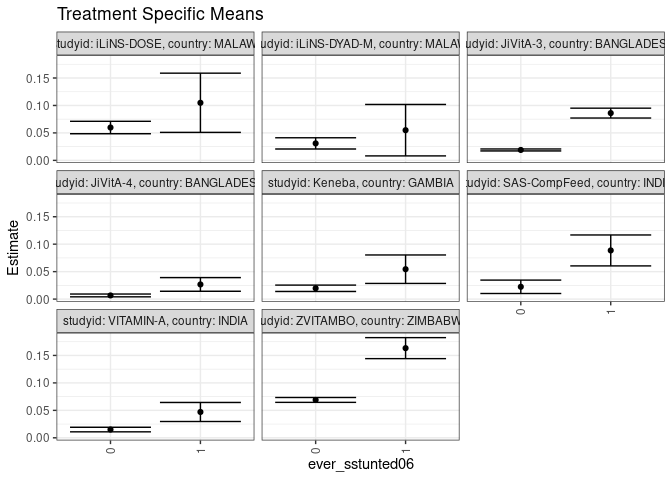

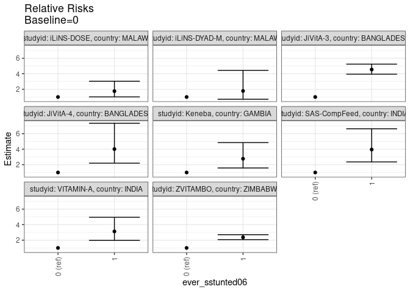

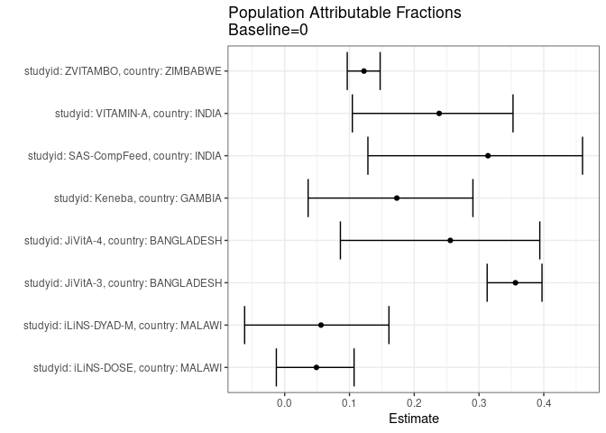

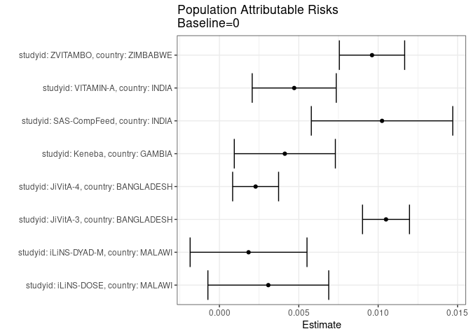

## Results Table

### Parameter: TSM

| studyid | country | intervention_level | baseline_level | estimate | ci_lower | ci_upper |
| --- | --- | --- | --- | --- | --- | --- |
| iLiNS-DOSE | MALAWI | 0 | NA | 0.0597987 | 0.0484875 | 0.0711099 |
| iLiNS-DOSE | MALAWI | 1 | NA | 0.1048387 | 0.0509040 | 0.1587734 |
| iLiNS-DYAD-M | MALAWI | 0 | NA | 0.0309091 | 0.0206771 | 0.0411411 |
| iLiNS-DYAD-M | MALAWI | 1 | NA | 0.0549451 | 0.0081066 | 0.1017835 |
| JiVitA-3 | BANGLADESH | 0 | NA | 0.0189576 | 0.0171627 | 0.0207524 |
| JiVitA-3 | BANGLADESH | 1 | NA | 0.0860974 | 0.0771076 | 0.0950872 |
| JiVitA-4 | BANGLADESH | 0 | NA | 0.0066381 | 0.0040615 | 0.0092147 |
| JiVitA-4 | BANGLADESH | 1 | NA | 0.0266667 | 0.0142290 | 0.0391043 |
| Keneba | GAMBIA | 0 | NA | 0.0196796 | 0.0138545 | 0.0255047 |
| Keneba | GAMBIA | 1 | NA | 0.0544218 | 0.0284861 | 0.0803574 |
| SAS-CompFeed | INDIA | 0 | NA | 0.0223938 | 0.0101909 | 0.0345967 |
| SAS-CompFeed | INDIA | 1 | NA | 0.0886076 | 0.0604552 | 0.1167600 |
| VITAMIN-A | INDIA | 0 | NA | 0.0150421 | 0.0109037 | 0.0191806 |
| VITAMIN-A | INDIA | 1 | NA | 0.0470383 | 0.0297158 | 0.0643609 |
| ZVITAMBO | ZIMBABWE | 0 | NA | 0.0689792 | 0.0645589 | 0.0733995 |
| ZVITAMBO | ZIMBABWE | 1 | NA | 0.1632938 | 0.1441551 | 0.1824325 |

### Parameter: E(Y)

| studyid | country | intervention_level | baseline_level | estimate | ci_lower | ci_upper |
| --- | --- | --- | --- | --- | --- | --- |
| iLiNS-DOSE | MALAWI | NA | NA | 0.0628792 | 0.0517023 | 0.0740561 |
| iLiNS-DYAD-M | MALAWI | NA | NA | 0.0327456 | 0.0226340 | 0.0428572 |
| JiVitA-3 | BANGLADESH | NA | NA | 0.0294518 | 0.0273600 | 0.0315436 |
| JiVitA-4 | BANGLADESH | NA | NA | 0.0089184 | 0.0062077 | 0.0116291 |
| Keneba | GAMBIA | NA | NA | 0.0237999 | 0.0177985 | 0.0298013 |
| SAS-CompFeed | INDIA | NA | NA | 0.0326371 | 0.0205116 | 0.0447625 |
| VITAMIN-A | INDIA | NA | NA | 0.0197537 | 0.0153848 | 0.0241226 |
| ZVITAMBO | ZIMBABWE | NA | NA | 0.0785917 | 0.0741435 | 0.0830400 |

### Parameter: RR

| studyid | country | intervention_level | baseline_level | estimate | ci_lower | ci_upper |
| --- | --- | --- | --- | --- | --- | --- |
| iLiNS-DOSE | MALAWI | 0 | 0 | 1.000000 | 1.000000 | 1.000000 |
| iLiNS-DOSE | MALAWI | 1 | 0 | 1.753194 | 1.013402 | 3.033041 |
| iLiNS-DYAD-M | MALAWI | 0 | 0 | 1.000000 | 1.000000 | 1.000000 |
| iLiNS-DYAD-M | MALAWI | 1 | 0 | 1.777634 | 0.712343 | 4.436041 |
| JiVitA-3 | BANGLADESH | 0 | 0 | 1.000000 | 1.000000 | 1.000000 |
| JiVitA-3 | BANGLADESH | 1 | 0 | 4.541588 | 3.939215 | 5.236073 |
| JiVitA-4 | BANGLADESH | 0 | 0 | 1.000000 | 1.000000 | 1.000000 |
| JiVitA-4 | BANGLADESH | 1 | 0 | 4.017204 | 2.197427 | 7.344011 |
| Keneba | GAMBIA | 0 | 0 | 1.000000 | 1.000000 | 1.000000 |
| Keneba | GAMBIA | 1 | 0 | 2.765385 | 1.578021 | 4.846167 |
| SAS-CompFeed | INDIA | 0 | 0 | 1.000000 | 1.000000 | 1.000000 |
| SAS-CompFeed | INDIA | 1 | 0 | 3.956787 | 2.360639 | 6.632173 |
| VITAMIN-A | INDIA | 0 | 0 | 1.000000 | 1.000000 | 1.000000 |
| VITAMIN-A | INDIA | 1 | 0 | 3.127108 | 1.974711 | 4.952017 |
| ZVITAMBO | ZIMBABWE | 0 | 0 | 1.000000 | 1.000000 | 1.000000 |
| ZVITAMBO | ZIMBABWE | 1 | 0 | 2.367291 | 2.071282 | 2.705603 |

### Parameter: PAR

| studyid | country | intervention_level | baseline_level | estimate | ci_lower | ci_upper |
| --- | --- | --- | --- | --- | --- | --- |
| iLiNS-DOSE | MALAWI | 0 | NA | 0.0030805 | -0.0007248 | 0.0068858 |
| iLiNS-DYAD-M | MALAWI | 0 | NA | 0.0018365 | -0.0018446 | 0.0055176 |
| JiVitA-3 | BANGLADESH | 0 | NA | 0.0104942 | 0.0090149 | 0.0119736 |
| JiVitA-4 | BANGLADESH | 0 | NA | 0.0022803 | 0.0008328 | 0.0037278 |
| Keneba | GAMBIA | 0 | NA | 0.0041203 | 0.0009369 | 0.0073037 |
| SAS-CompFeed | INDIA | 0 | NA | 0.0102433 | 0.0057889 | 0.0146976 |
| VITAMIN-A | INDIA | 0 | NA | 0.0047116 | 0.0020649 | 0.0073583 |
| ZVITAMBO | ZIMBABWE | 0 | NA | 0.0096126 | 0.0075558 | 0.0116694 |

### Parameter: PAF

| studyid | country | intervention_level | baseline_level | estimate | ci_lower | ci_upper |
| --- | --- | --- | --- | --- | --- | --- |
| iLiNS-DOSE | MALAWI | 0 | NA | 0.0489909 | -0.0129086 | 0.1071077 |
| iLiNS-DYAD-M | MALAWI | 0 | NA | 0.0560839 | -0.0618845 | 0.1609468 |
| JiVitA-3 | BANGLADESH | 0 | NA | 0.3563189 | 0.3125848 | 0.3972706 |
| JiVitA-4 | BANGLADESH | 0 | NA | 0.2556836 | 0.0859905 | 0.3938719 |
| Keneba | GAMBIA | 0 | NA | 0.1731218 | 0.0361595 | 0.2906217 |
| SAS-CompFeed | INDIA | 0 | NA | 0.3138533 | 0.1284525 | 0.4598145 |
| VITAMIN-A | INDIA | 0 | NA | 0.2385172 | 0.1044299 | 0.3525286 |
| ZVITAMBO | ZIMBABWE | 0 | NA | 0.1223103 | 0.0965597 | 0.1473269 |